# Trabalho de Grupo - MBIOINF

# Correlação da variavel dependente com a interação entre todas as variaveis independente exceto DepressionBefore

H0: A depressão depois do uso de internet não é correlacionado com o número de horas médias de uso de internet por semana, o género, a idade, a etnia, o salário anual e o tamanho do agregado familiar. H1: A depressão depois do uso de internet é correlacionado com o número de horas médias de uso de internet por semana, o género, a idade, a etnia, o salário anual e o tamanho do agregado familiar.

```r
model_final = lm (da~dati$Internet.use..mean.hours.per.week.+dati$Gender+dati$Race..white...1..minority...0.+dati$Age+dati$Household.income...000.+dati$Household.size)
model_final
```

```
##
## Call:
## lm(formula = da ~ dati$Internet.use..mean.hours.per.week. + dati$Gender +
##     dati$Race..white...1..minority...0. + dati$Age + dati$Household.income...000. +
##     dati$Household.size)
##
## Coefficients:
##                             (Intercept)
##                               0.7467026
## dati$Internet.use..mean.hours.per.week.
##                               0.0209114
##                         dati$Gendermale
##                               0.0136471
##     dati$Race..white...1..minority...0.
##                              -0.1776104
##                            dati$AgeTeen
##                               0.1244599
##            dati$Household.income...000.
##                               0.0001301
##                     dati$Household.size
##                              -0.0225065
```

```r
summary(model_final)
```

```
##
## Call:
## lm(formula = da ~ dati$Internet.use..mean.hours.per.week. + dati$Gender +
##     dati$Race..white...1..minority...0. + dati$Age + dati$Household.income...000. +
##     dati$Household.size)
##
## Residuals:
##      Min       1Q   Median       3Q      Max
## -0.76041 -0.27392 -0.07115  0.18129  2.24794
##
## Coefficients:
##                                           Estimate Std. Error t value Pr(>|t|)
## (Intercept)                              0.7467026  0.1423489   5.246  5.3e-07
## dati$Internet.use..mean.hours.per.week.  0.0209114  0.0077575   2.696  0.00784
## dati$Gendermale                          0.0136471  0.0771627   0.177  0.85986
## dati$Race..white...1..minority...0.     -0.1776104  0.0959964  -1.850  0.06628
## dati$AgeTeen                             0.1244599  0.0897680   1.386  0.16769
## dati$Household.income...000.             0.0001301  0.0017498   0.074  0.94083
## dati$Household.size                     -0.0225065  0.0325568  -0.691  0.49046
##
## (Intercept)                             ***
## dati$Internet.use..mean.hours.per.week. **
## dati$Gendermale
## dati$Race..white...1..minority...0.     .
## dati$AgeTeen
## dati$Household.income...000.
## dati$Household.size
## ---
## Signif. codes:  0 '***' 0.001 '**' 0.01 '*' 0.05 '.' 0.1 ' ' 1
##
## Residual standard error: 0.4568 on 148 degrees of freedom
## Multiple R-squared:  0.08841,    Adjusted R-squared:  0.05146
## F-statistic: 2.392 on 6 and 148 DF,  p-value: 0.03097
```

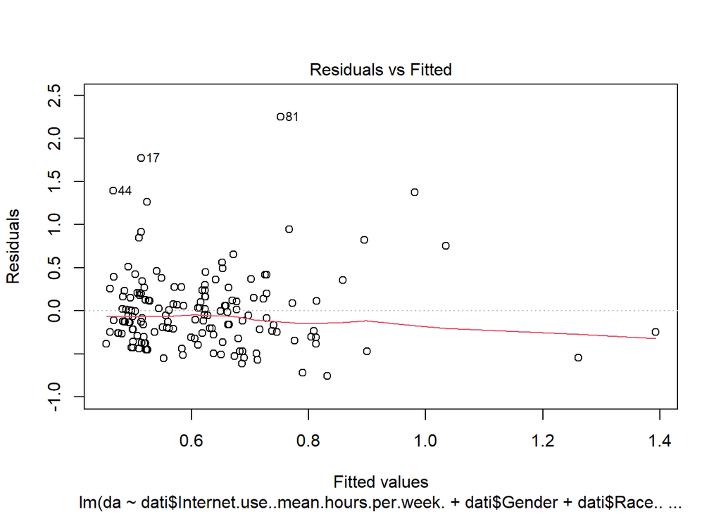

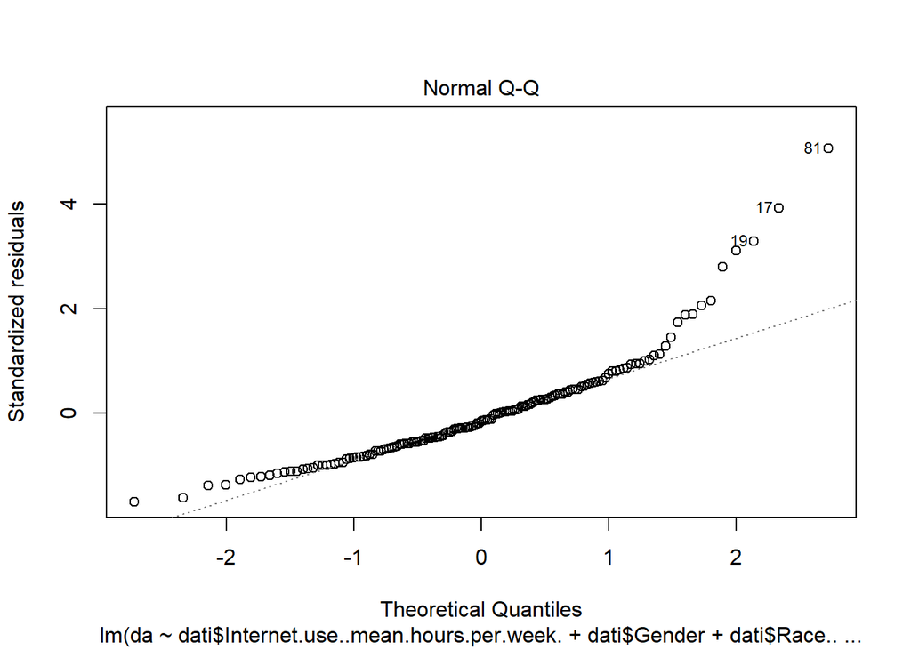

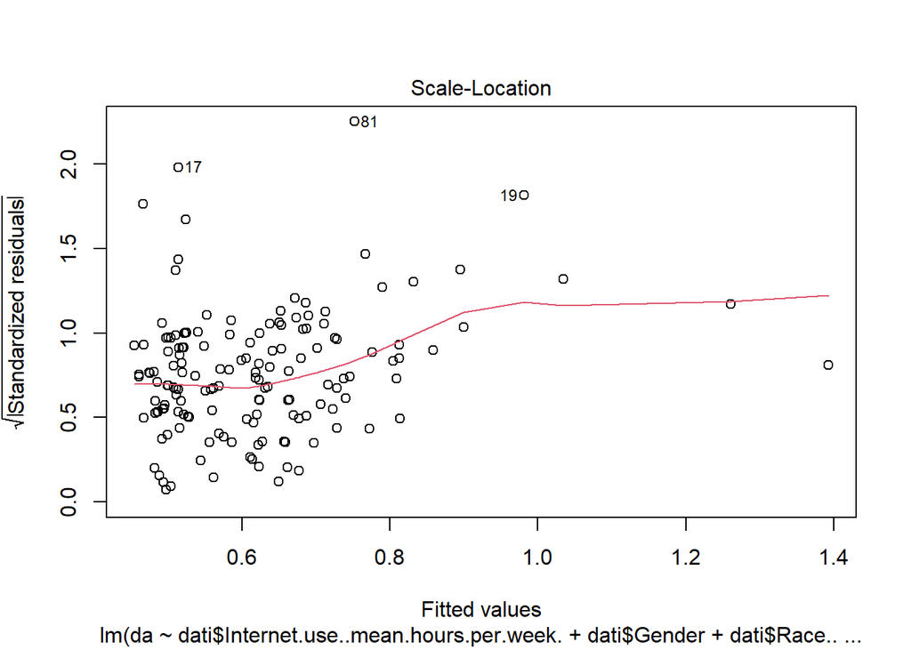

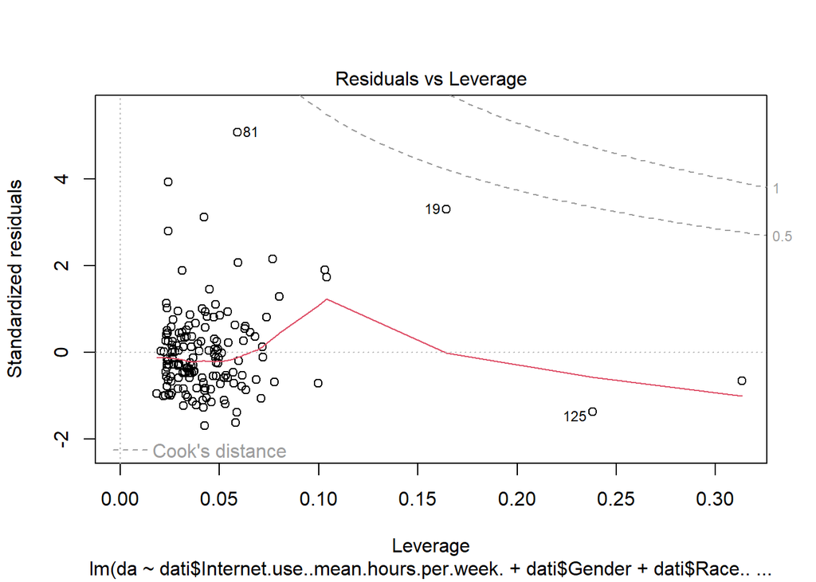

```r
plot(model_final)
```

# Matriz de correlações

Transformar variáveis em valores numéricos.

```r
depression.and.the.internet[depression.and.the.internet=="female"] <- 1
depression.and.the.internet[depression.and.the.internet=="male"] <-0

depression.and.the.internet[depression.and.the.internet=="Adult"] <- 1
depression.and.the.internet[depression.and.the.internet=="Teen"] <- 0

DATI <- transform(depression.and.the.internet, Age=as.numeric(Age),
               Gender = as.numeric(Gender))
```

Matriz de correlações.

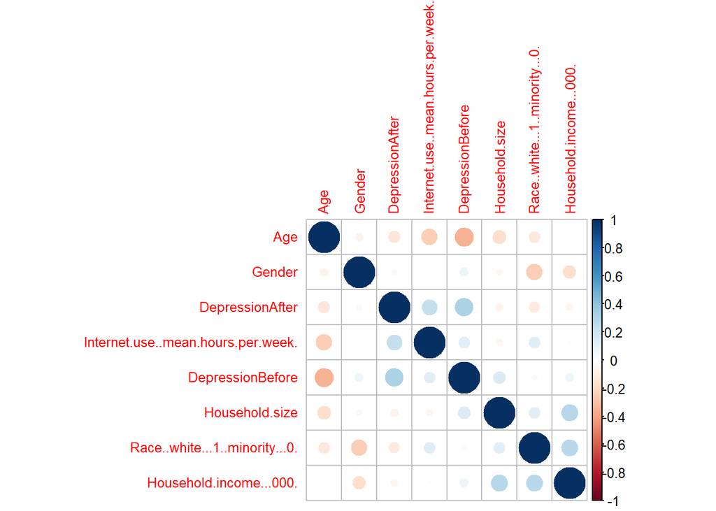

```r
library(corrplot)
subc<-subset(DATI)
M<-cor(subc, use="complete.obs")
corrplot(M, order = "AOE", tl.cex = 0.80 )
```

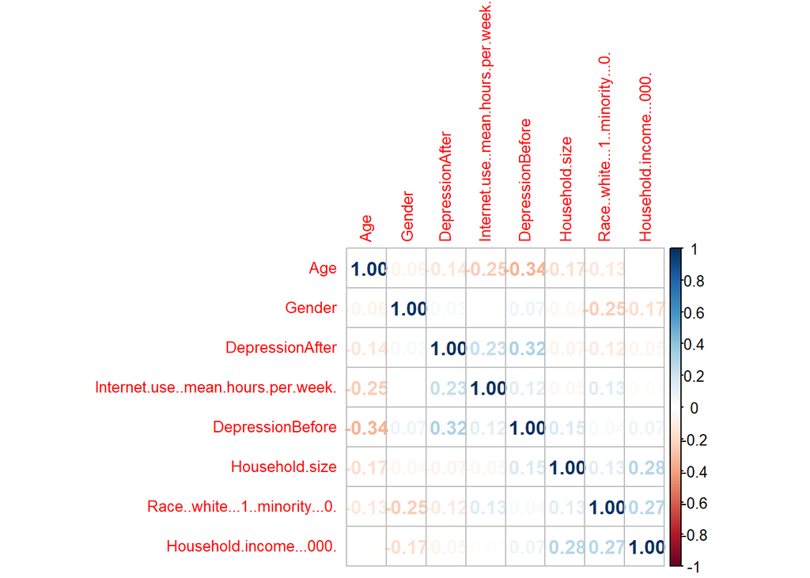

```r
corrplot(M, order = "AOE",method = 'number',tl.cex = 0.80)
```

Verificamos com esta matriz, um certo grau de correlação entre a depressão depois do uso de internet com o número de horas médias passadas na internet por semana e a depressão antes do seu uso.  
Verificamos tambem uma certa correlação, entre o tamanho do agregado familiar com o seu salário anual, assim como a etnia e o salário anual do respetivo agregado.